# Demographic Exploration and Discovery

Tim Riffe

May 8, 2019

These are the actual class notes from the session. The other docs (VizNotes) were my preparation, less useful for you, apologies for the clutter.

We’re starting here: https://socviz.co/makeplot.html#aesthetics-can-be-mapped-per-geom

Here is an example of all geoms *sharing* a mapping because it was given in `ggplot()`. Ergo, everything is grouped in the same way.

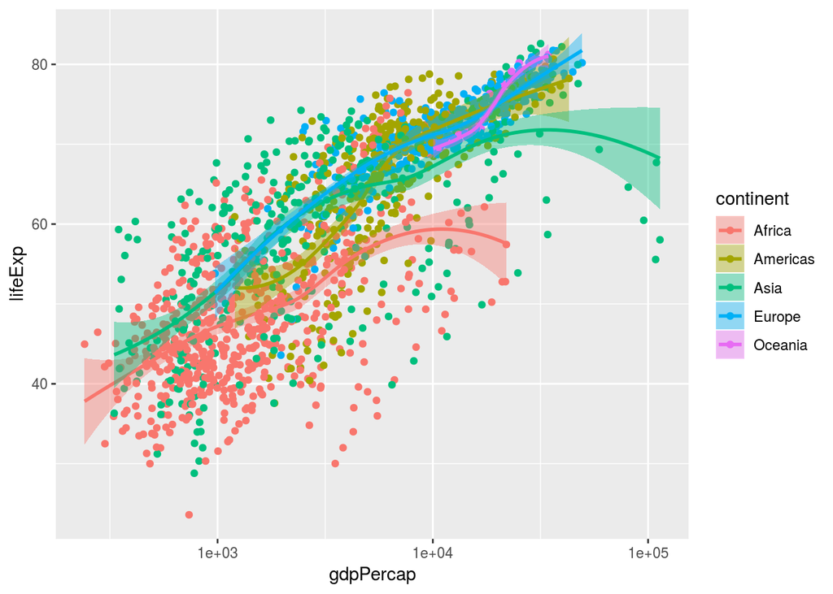

```r
p <- ggplot(data = gapminder,
            mapping = aes(x = gdpPercap,
                          y = lifeExp,
                          color = continent, fill = continent))
p + geom_point() +
    geom_smooth(method = "loess") +
    scale_x_log10()
```

Wow, that plot is kinda fancy, but it’s oversaturated and hard to pick out meaningful patterns, #amiright? How can we have the same points but with just one smoother? Give the mapping in the geom!

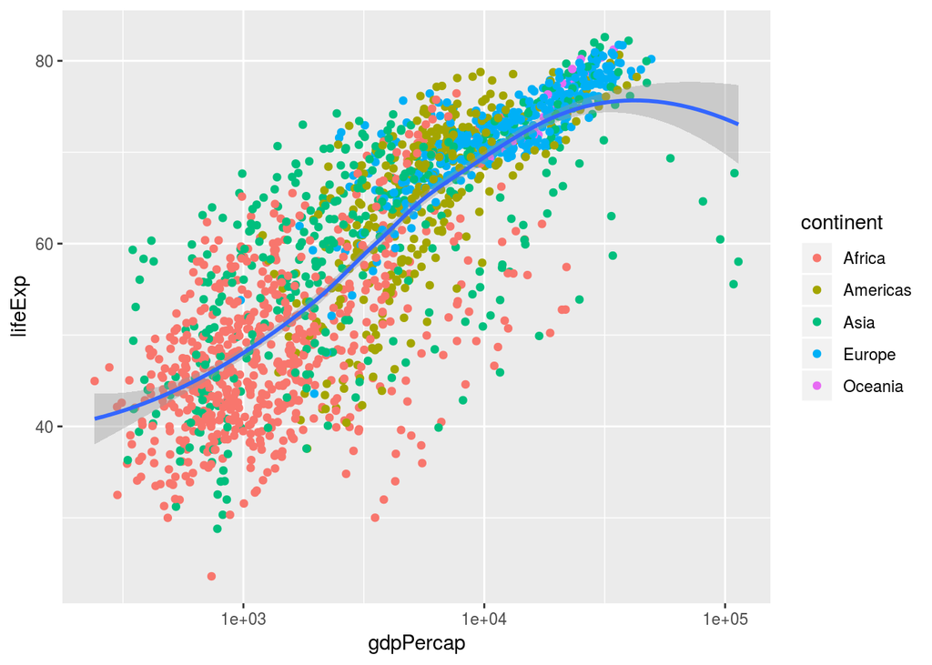

```r
p <- ggplot(data = gapminder, gapminder,
            mapping = aes(x= gdpPercap, y = lifeExp))
# notice the color mapping moved down to geom_point()
p + geom_point(mapping = aes(color = continent)) +
# no color mapping for geom_smooth() implies just once over all data
    geom_smooth(method = "loess") +
    scale_x_log10()
```

Lesson: you can choose which `geom` elements abide by which mappings by specifying them inside the `geom` functions instead of giving them a global mapping in the `ggplot()` function.

## saving

Moral: save as a vector graphic: the platonic perfect form of a well-produced data visualization, infinitely zoomable and lossless. Vector options are `pdf`or `svg`. But usually better to stick with `pdf` (because it support transparency when saving from `R`).

Don’t save in raster formats, such as `JPEG` unless it’s a photo in a natural setting- they don’t work well in high contrast environments, especially if they contain straight lines of contrast. But there are other raster formats that are not so bad, like `png` or `tiff` because they don’t lose information– they save it faithfully to the level of resolution that you specify. If saving to `png`, 300 dpi is just fine, unless it’s for publication or poster printing, in which case 600 dpi is better (as long as the printers actually print it that way!).

So, let’s save a plot to pdf first:

```r
# same plot from above, will just assign it to an object
# to be explicit about saving it out
p <- ggplot(data = gapminder, gapminder,
            mapping = aes(x= gdpPercap, y = lifeExp))
p <- p + geom_point(mapping = aes(color = continent)) +
    geom_smooth(method = "loess") +
    scale_x_log10()

# the working directory
here()
```

```
## [1] "/home/tim/workspace/DemoED"
```

```r
# you'll have to change this path-- it's always relative to the working
# directory
ggsave(filename = here("Lecture_08052019", "PrestonMeetsRosling.pdf"),
       plot = p,
       height = 15, width = 15, units = "cm")

# repeat for png
ggsave(filename = here("Lecture_08052019", "PrestonMeetsRosling.png"),
       plot = p,
       dpi = 300, # this argument gives resolution.
       height = 15, width = 15, units = "cm")
```

## real quick `facet_wrap()`

Facetting is ggplot lingo for making plots by groups and arranging them on a grid, also known as small multiples, or some kinds of panel plots.

This is from the second code chunk in section 4.2: https://socviz.co/groupfacettx.html#facet-to-make-small-multiples

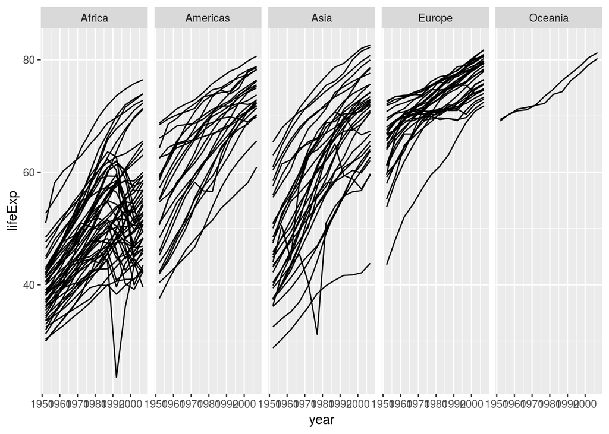

```r
p <- ggplot(data = gapminder,
            mapping = aes(x = year,
                          y = lifeExp))
p + geom_line(aes(group = country)) +
    facet_wrap(~continent, ncol = 5)
```

## Cross-tab facetting

To do more tricks with dimensionality and geoms it’s better to work with some more high dimensional data, like The General Social Survey (GSS).

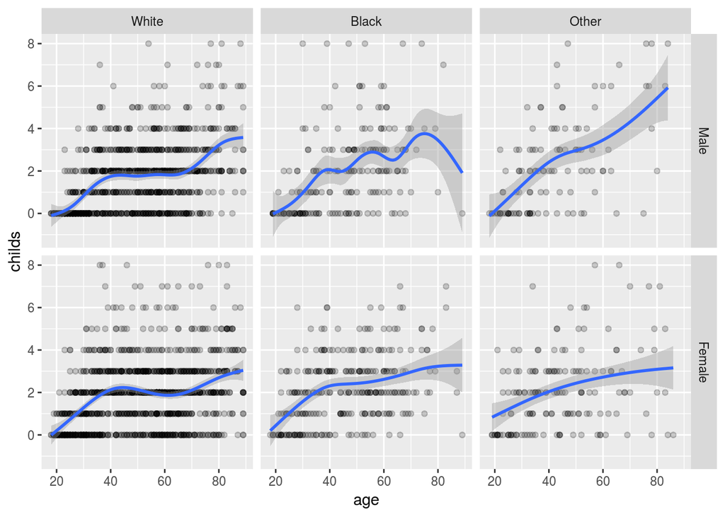

```r
#glimpse(gss_sm)
p <- ggplot(data = gss_sm,
            mapping = aes(x = age, y = childs))
p + geom_point(alpha = .2) +
    geom_smooth() +
    facet_grid(sex~race)
```

Without the facet wrap this would be highly overlapped data (overplotting), but we can squeeze out group differences by doing the same thing for different *intersections* in the data. Operating on groups in this way is similar to interacting variables in a regression setting, or doing cross-tabulations in an aggregate setting. The same smoother specification gets fit to each subset of the data. The coefficients of the smoother don’t matter, it just gives a feel for the average pattern over age, and the points give a sense of the spread in the data. What would be better a better way to display the information in the points here?

## WAPO graphic

Jumping to the end of the chapter- the WAPO graphic here:https://socviz.co/groupfacettx.html#avoid-transformations-when-necessary. This example showcases `geom_col()`, which is just like `geom_bar()` but with friendlier defaults for plotting aggregate magnitudes like these LE differences. Otherwise `geom_bar` would rescale the data in undesired ways.

```r
glimpse(oecd_sum)
```

```
## Observations: 57
```

```
## Variables: 5
## Groups: year [57]
## $ year  <int> 1960, 1961, 1962, 1963, 1964, 1965, 1966, 1967, 1968, 1969…
## $ other <dbl> 68.6, 69.2, 68.9, 69.1, 69.5, 69.6, 69.9, 70.1, 70.1, 70.1…
## $ usa   <dbl> 69.9, 70.4, 70.2, 70.0, 70.3, 70.3, 70.3, 70.7, 70.4, 70.6…
## $ diff  <dbl> 1.3, 1.2, 1.3, 0.9, 0.8, 0.7, 0.4, 0.6, 0.3, 0.5, 1.1, 0.8…
## $ hi_lo <chr> "Below", "Below", "Below", "Below", "Below", "Below", "Bel…
```

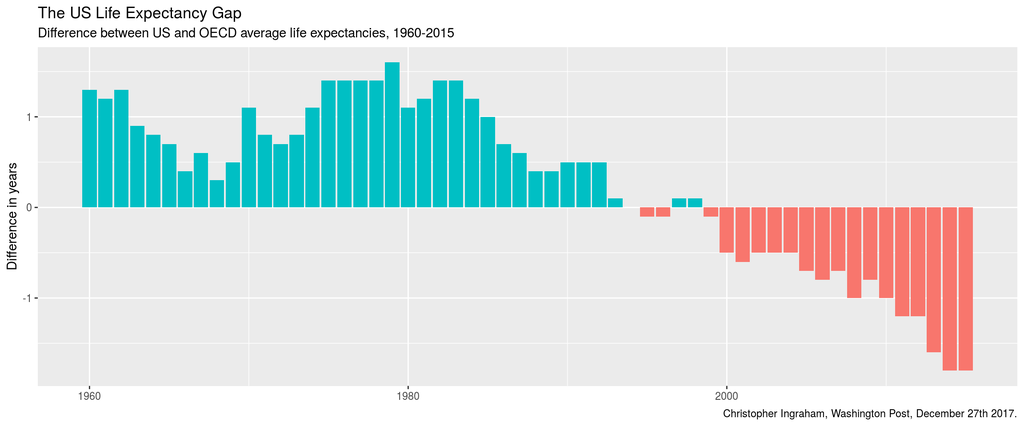

```r
p <- ggplot(data = oecd_sum, mapping = aes(x = year,
                                           y = diff,
                                           fill = hi_lo))
p + geom_col() + guides(fill = FALSE) +
    labs(x = NULL, y = "Difference in years",
         title = "The US Life Expectancy Gap",
         subtitle = "Difference between US and OECD average life expectancies, 1960-2015",
         caption = "Christopher Ingraham, Washington Post, December 27th 2017.")
```

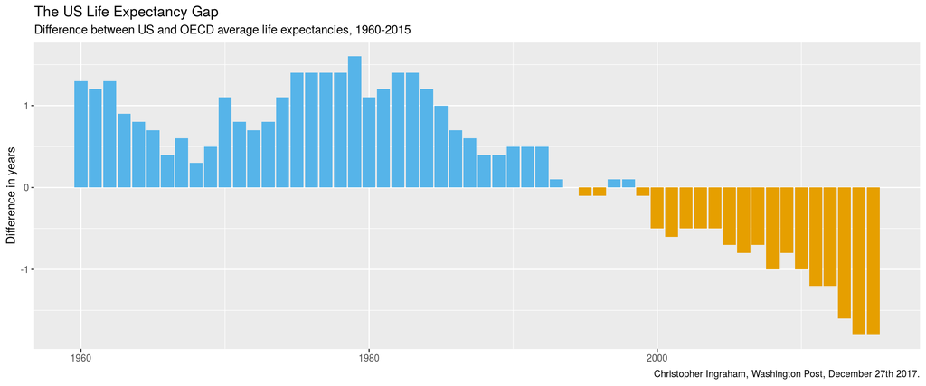

```r
p <- ggplot(data = oecd_sum, mapping = aes(x = year,
                                           y = diff,
                                           fill = hi_lo))
p + geom_col() +
    # colors manually set here-- you can use a color picker
    scale_fill_manual(values=c("#E69F00", "#56B4E9")) +
    guides(fill = FALSE) +
    labs(x = NULL, y = "Difference in years",
         title = "The US Life Expectancy Gap",
         subtitle = "Difference between US and OECD average life expectancies, 1960-2015",
         caption = "Christopher Ingraham, Washington Post, December 27th 2017.")
```

or instead of doing it manually (OK here cuz it’s just two colors) you can check out the functions called `scale_fill_...()`, where `...` might be something like `brewer` for a brewer palette, etc. I’ll demonstrate this soon.